# Detecting treatment effects with instrumental variables

Elaine Chiu

The causal inference project I am working on aims to answer if the Medicaid health insurance plan reopened in Oregon during 2008 has the positive causal effect on residents’ mental and physical health. From this study, the method to detect causal effect with instrumental variable is also developed.

# The Data Set

# The Answer this Study Seeks

We often assume that the treatment effect might be the same across the individuals, ignoring the random errors. However, this study assume that some recipients of the treatment might benefit from the treatment more than other recipients. For example, the treatment, in this study, the enrollment of health insurance, might benefit sick people more than healthy people. As a result, this study aims to estimate the heterogeneous complier average causal effect. (H-CACE). When it comes the compliance , we can classify people into four categories: Compliers are units which their treatment values follow their instrument/ assignment of treatment values; always-takers always take the treatment regardless of their assignments; never-takers never take the treatment regardless of their assignments; defiers act against their assignment values. While compliance is taken into consideration, if we want to find a point estimate of the average treatment effect, instead of having bounds only, we would need to assume monotonicity. Monotonicity states that the potential treatment is a monotonic function of the assignments. In other words, we would need to assume there is no defiers.  
The complier causal average effect(CACE) is defined as the expected difference between the outcomes under treatment and control. The H-CACE is defined as the CACE for a subgroup of compliers with a specific value of pre-treament covariates.

# The Techniques Involved

To be able to show causation not only association, we often need to get rid of the confounding effects. a confounder is a variable impacts both the treatment assignment and potential outcomes, causing a spurious association. The ideal that randomized experiments can achieve is it makes sure the assignment of treatment is unrelated to the potential outcomes. A tenique to mimic this ideal is via matching - we pair the recipients based on the similarities of the covariates, which might be confounders, and assignment treatment or control to these paired recipients and observe the difference between their responses. However, this technique can only deal with the confounding effects coming from obeserved covariates. For those unobserved covariates , we cannot do matching based on those. Consequently, this study also considers the use of instrumental variable. Instrumental variable is an approach to analysize causal effects when unmeasured confounding is present. Consider the following causal graph.

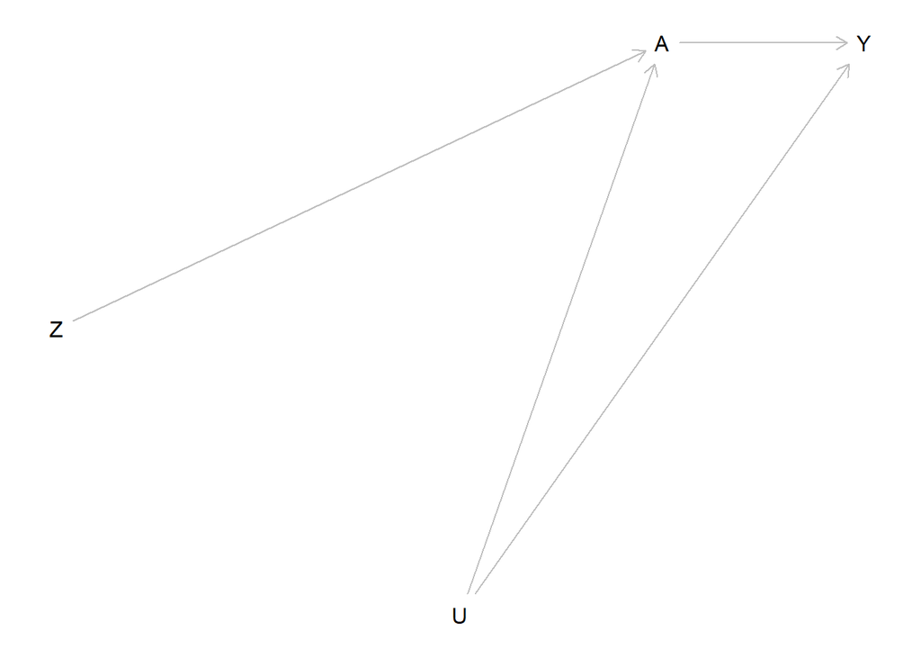

```r
library(dagitty)
dag <- dagitty("dag {
  U-> A
  U -> Y
  Z -> A -> Y
               }")

coordinates( dag ) <-  list(
  x=c(Z=1, A=4, U=3, Y=5),
  y=c(Z=3, A=2, U=4, Y=2) )
plot( dag )
```

$A$ is the treatment variable, $Y$ is the outcome variable, $U$ stands for the unobserved confounder, and $Z$ is the instrumental variable. Because the confounder is unobserved, we cannnot block the spurious association path via conditioning. Instrumental variable approach proposes that we first measure the covariance between $Z$ and $Y$, for this to detect the causal effect from $Z$ to $Y$ via the path $Z \rightarrow A \rightarrow Y$, and then divide this by the covariance between $Z$ and $A$.

# Before The Identification of Causal Effect - Assumptions for Instrumental Variables, and why to use them?

Recall that based on the causal graph above, we want to find the causal effect from the treatment $A$ to outcome variable $Y$. However, we suspect that there are unmeasured cofounders $U$. Because $U$ is unmeasured, we cannot condition on $U$ to identify our causal estimand. We turn to the use of instrument $Z$. While we escape from the unmeasured variable problem by avoiding using adjustment for confounders. We need another set of assumptions for instrumental variable $Z$.

## i

Instrument $Z$ is associate with treatment $A$.

## ii

$Z$ does not affect $Y$ except through its potential effect on treatment $A$.

## iii

Instrument $Z$ and outcome $Y$ do not share any common causes.

## iv Monotonicity

Instrument $Z$ only increases the level of treatment $A$. This is an important assumption to allow us identify the causal estimand. We detail the assumption of monotonicity below.  
Imagine that $Z$ can be seen as a “encouragement” variable might urge an individual to take the treatment. $Z=0$ means the individual is not encouraged to take the treatment $A=1$, and $Z=1$ means the individual receives the encouragement to take the treatment $A=1$. Some examples are:

- $Z$ is a higher pricing on cigaratte, and $A$ is the cessation of smoking.
- $Z$ is a shorter distance to the clinic, and $A$ is to go to see the doctor.

We can define potential treatment taken by the indvidual as a function of the instrument. For example, $A^{Z=1} = 1$ means that this individual would take the treatment, after receiving the encouragement. $A^{Z=1} = 0$ means even if the individual does receive the encouragement to take the treatment, he would refuse the take the treatment. Based on this notation, we can have four subpopulations based on their behavior in terms of the compliance.

- Always-takers:  
  Individuals who will always take teratment, regardless of the treatment group they were assigned to. That is, $A^{Z=1} = 1 = A^{Z=0}$.
- Never-takers:  
  Individuals who will never take treatment, regardless of the treatment group they were assigned to. That is, $A^{Z=1} = 0 = A^{Z=0}$.
- Compliers:  
  Individuals who would take the treatment based on what they were encouraged to. That is, $A^{Z=1} = 1$; $A^{Z=0} = 0$.
- Defiers:  
  Individuals who would would take the other treatment as opposed to what they were encouraged to. That is, $A^{Z=1}=0$; $A^{Z=0}=1$.

Note that these subpopulations are not identifiable. For example, if you encourage an individual to take the treatment and he did, he could be either an always-taker or a complier.  
When no defiers exist, we say that there is monotonicity because the instrument $Z$ either does not change the level of treatment $A$ or increases the level of treatment $A$.

Generally, monotonicity holds when $A^{Z=1} \geq A^{Z=0}$ for all individuals.

# The Identification of The causal Estimand - The Average Treatment Effect of Compliers

We now want to show that we can identify the the average treatment effect of compliers. Define the following notations.  
Let $Y$ be the outcome variable, $A$ be the treatment variable, $Z$ be the instrument. Furthermore, through our derivation, we use the superscript to denote the potential outcome under specific intervention. Recall that $A^{Z=0}$ is the potential treatment that an individual would take if we intervene to make the instrument $Z = 0$. Similar to this notation, $Y^{A=a}$ means the potential outcome when the individual takes the treatment $A=a$; $Y^{Z=0}$ means the potential outcome when the individual receives the instrument, $Z=0$. As a sidenote, one should always remember the differences between $Y^{A=1}$, $Y|A=1$, $Y^{A=0}|A=1$, and $Y^{A=1}|A=1$. In general, the conditioning shows if the individual receives the treatment or not in real life, while the potential outcome imagines a parallel universe, consider the outcome when the same individual receives a specific treatment.

- $Y^{A=1}$ means the potential outcome of this individual when he receives treatment $A=1$.
- $Y|A=1$ means the outcome value when an individual receives the treatment $A=1$ in real life.
- $Y^{A=0}|A=1$ means that we wonder the potential outcome value assuming this individual receives treatment $A=0$, while he receives treatment $A=1$ in real life.
- $Y^{A=1}|A=1$ means that we wonder the potential outcome value assuming this individual receives treatment $A=1$, while he indeed receives treatment $A=1$ in real life.

With these notations, we want to identify the average treatment effect of compliers.

$$\mathbb{E}(Y^{a=1} - Y^{a=0}|A^{Z=1}=1, A^{Z=0}=0)$$

In particular, we want to show that, provided that we have the four assumptions, we have:

$$\mathbb{E}(Y^{a=1} - Y^{a=0}|A^{Z=1}=1, A^{Z=0}=0) =
\frac{\mathbb{E}(Y|Z=1) - \mathbb{E}(Y|Z=0)}{\mathbb{E}(A|Z=1) -
\mathbb{E}(A|Z=0)}$$

$$\begin{align}
\mathbb{E}(Y^{Z=1} - Y^{Z=0}) &= \mathbb{E}(Y^{Z=1} -
Y^{Z=0}|A^{Z=1}=1, A^{Z=0}=1) \mathbb{P}(A^{Z=1}=1, A^{Z=0}=1)
\text{ (always-takers)} \\
& + \mathbb{E}(Y^{Z=1} - Y^{Z=0}|A^{Z=1}=0, A^{Z=0}=0)
\mathbb{P}(A^{Z=1}=0, A^{Z=0}=0) \text{ (never-takers)}\\
& + \mathbb{E}(Y^{Z=1} - Y^{Z=0}|A^{Z=1}=1, A^{Z=0}=0)
\mathbb{P}(A^{Z=1}=1, A^{Z=0}=0) \text{ (compliers)}\\
& + \mathbb{E}(Y^{Z=1} - Y^{Z=0}|A^{Z=1}=0, A^{Z=0}=1)
\mathbb{P}(A^{Z=1}=0, A^{Z=0}=1) \text{ (defiers)}\\
& = \mathbb{E}(Y^{A=1} - Y^{A=1})\cdot \mathbb{P}(A^{Z=1}=1,
A^{Z=0}=1) \\
& + \mathbb{E}(Y^{A=0} - Y^{A=0}) \cdot \mathbb{P}(A^{Z=1}=0,
A^{Z=0}=0) \\
& + \mathbb{E}(Y^{Z=1} - Y^{Z=0}|A^{Z=1}=1, A^{Z=0}=0)
\mathbb{P}(A^{Z=1}=1, A^{Z=0}=0) \\
& + \mathbb{E}(Y^{Z=1} - Y^{Z=0}|A^{Z=1}=0, A^{Z=0}=1)
\mathbb{P}(A^{Z=1}=0, A^{Z=0}=1) \\
& = 0 \cdot \mathbb{P}(A^{Z=1}=1, A^{Z=0}=1) \\
& + 0 \cdot \mathbb{P}(A^{Z=1}=0, A^{Z=0}=0) \\
& + \mathbb{E}(Y^{Z=1} - Y^{Z=0}|A^{Z=1}=1, A^{Z=0}=0)
\mathbb{P}(A^{Z=1}=1, A^{Z=0}=0) \\
& + \mathbb{E}(Y^{Z=1} - Y^{Z=0}|A^{Z=1}=0, A^{Z=0}=1) \cdot 0 \\
& = \mathbb{E}(Y^{Z=1} - Y^{Z=0}|A^{Z=1}=1, A^{Z=0}=0)
\mathbb{P}(A^{Z=1}=1, A^{Z=0}=0) \\
\end{align}$$

The first equality comes from that for always-takers and never-takers, the instrument $Z$ does not have any impact on the treatment they take. The second equality comes from we assume there is no defier in the population.  
As a result, we obtain that:

$$\mathbb{E}(Y^{Z=1} - Y^{Z=0}) = \mathbb{E}(Y^{Z=1} - Y^{Z=0}|A^{Z=1}=1,
A^{Z=0} = 0) \mathbb{P}(A^{Z=1}=1, A^{Z=0}=0)$$

Furthermore, recall that under our assumptions, in the subpopulation of compliers, the effect of $Z$ on $Y$ equals the effect of $A$ on $Y$, because $Z=A$, and also we assume for $Z$ to be an instrument, the effect of $Z$ on $Y$ only passes through $A$. Consequently,

$$\mathbb{E}(Y^{Z=1} - Y^{Z=0}| A^{Z=1} = 1, A^{Z=0} = 0) =
\mathbb{E}(Y^{A=1} - Y^{A=0}|A^{Z=1}=1, A^{Z=0}=0)$$

With this realization, we have:

$$\begin{align}
& \mathbb{E}(Y^{Z=1} - Y^{Z=0}) = \mathbb{E}(Y^{A=1} -
Y^{A=0}|A^{Z=1}=1, A^{Z=0} = 0) \mathbb{P}(A^{Z=1}=1, A^{Z=0}=0) \\
& \mathbb{E}(Y^{A=1} - Y^{A=0}|A^{Z=1}=1, A^{Z=0}=0) =
\frac{\mathbb{E}(Y^{Z=1} - Y^{Z=0})}{ \mathbb{P}(A^{Z=1}=1, A^{Z=0} =
0)} \\
\end{align}$$

Under our assumption that $Z$ is random, we have that $Z$ is independent of $A^Z$ or $Y^A$.

$$\mathbb{E}(Y^{Z=1} - Y^{Z=0}) = \mathbb{E}(Y^{Z=1}) -
\mathbb{E}(Y^{Z=0}) = \mathbb{E}(Y^{Z=1}|Z=1) - \mathbb{E}(Y^{Z=0}|Z=0)$$

By $Z$ is random and consistency.

As for the simplification of the proportion of compliers in the population:

$$\begin{align}
\mathbb{P}(A^{Z=1}=1, A^{Z=0} = 0) & = \mathbb{P}(A^{Z=1}=1) -
\mathbb{P}(A^{Z=1}=1, A^{Z=0}=1) \\
& = \mathbb{P}(A^{Z=1}=1) - \mathbb{P}(A^{Z=0}=1) -
\mathbb{P}(A^{Z=0}=1, A^{Z=1}=0) \\
& = \mathbb{P}(A^{Z=1}=1) - \mathbb{P}(A^{Z=0}=1)\text{ because
we asssume no defiers} \\
& = \mathbb{P}(A^{Z=1}=1|Z=1) -
\mathbb{P}(A^{Z=0}=1|Z=0)\text{ because we have } Z \text{
independent of } A^Z \\
& = \mathbb{P}(A=1|Z=1) - \mathbb{P}(A=1|Z=0)\text{ By
Consistency} \\
\end{align}$$

In the special case that $A$ is binary that $A \in$ {$0$ ,$1$}, $\mathbb{P}(A=1|Z=1) = \mathbb{E}(A=1|Z=1)$; $\mathbb{P}(A=1|Z=0) = \mathbb{E}(A|Z=0)$.  
Finally, we identify that:

$$\mathbb{E}(Y^{A=1} - Y^{A=0}|A^{Z=1}=1, A^{Z=0}=0) =
\frac{\mathbb{E}(Y|Z=1) - \mathbb{E}(Y|Z=0)}{\mathbb{E}(A|Z=1) -
\mathbb{E}(A|Z=0)}$$

# Estimation with Data

We obtained our data set from National Bureau of Economic Research, the data set can be found here.

https://www.nber.org/research/data/oregon-health-insurance-experiment-data

Recall that we want to estimate our causal effects as:

$$\frac{\mathbb{E}(Y|Z=1) - \mathbb{E}(Y|Z=0)}{\mathbb{E}(A|Z=1) -
\mathbb{E}(A|Z=0)}$$

```r
library(haven)
lottery.Data = read_dta("C:/Users/Patron/Desktop/OHIE_Public_Use_Files/OHIE_Data/oregonhie_descriptive_vars.dta")

health.Data = read_dta("C:/Users/Patron/Desktop/OHIE_Public_Use_Files/OHIE_Data/oregonhie_ed_vars.dta")

inperson.Data = read_dta("C:/Users/Patron/Desktop/OHIE_Public_Use_Files/OHIE_Data/oregonhie_inperson_vars.dta")
```

```r
order.health.Data = health.Data[order(health.Data$person_id),]
order.health.Data
```

# Detection of Causal Effect on the Response - health_change_inp

`health_change_inp` is a self-reported assessment of health status compared to 12 months ago. In particular, is the answer to Comp the following question, compared with 12 months ago, would you say that your health is now:

```r
Data1 = merge(lottery.Data, order.health.Data, by = "person_id",all.x = TRUE)
Data1 = merge(Data1,inperson.Data,by="person_id", all.x = TRUE)

# pick a couple of health measures among those people who got the lottery/ encouragement Z = 1 and Z = 0
Data2=Data1[,c("person_id","treatment","health_change_inp","sf4_inp","gender_inp","age_inp","approved_app","phqtot_inp","pcs8_score_inp")]


## first estimate the denominator, which is the proportion of people who got into the insurance, given they were granted the chance to enter the insurance system/won the lottery

table1 = table(Data2[Data2$treatment==1,]$approved_app)
names(table1) = c("not enroll after lottery","enroll after lottery")

## out of all 29799 people who won the lottery, 8698 people choose to enter the insurance system, thus the denominator is 0.291889

denominator = 8698/(21101+8698)

# the numerator
# first use the health_change_inp as response y
# we get rid of the rows with NA in health_change_inp

health.Change.Data = Data2[complete.cases(Data2[ , c('health_change_inp')]), ]

# calculate the mean of the response health change conditioning on the people who won the lottery
# also notice that the original label is 0 better, 1 worse, 2 about the same, so we would need to relabel to make the orderiing meaningful

index = seq(1,length(health.Change.Data$health_change_inp))
index.better = index[health.Change.Data$health_change_inp==0]
index.worse = index[health.Change.Data$health_change_inp==1]
index.same = index[health.Change.Data$health_change_inp==2]


## relabel
health.Change.Data$order.health.change = rep(0,12226)
health.Change.Data$order.health.change[index.better]=2
health.Change.Data$order.health.change[index.same]=1
health.Change.Data$order.health.change[index.worse]=0

ya_1 = mean(health.Change.Data[health.Change.Data$treatment==1,]$order.health.change)


ya_0 = mean(health.Change.Data[health.Change.Data$treatment==0,]$order.health.change)

## calculate the causal effect of insurance on how people feel about their health change. 0: worse; 1:the same; 2: better, we detect an increase
cat("causal effect on how people feel about their health", (ya_1 - ya_0)/denominator)
```

```
## causal effect on how people feel about their health 0.05536323
```

# Detection of Causal Effect on Response - phqtot_inp, a measure of depression

`phqtot_inp` stands for PHQ total severity score, which provides a measure of depression symptoms as measured by the PHQ-8 scale (range=0-24). A high score indicates more symptioms of depression. The variable was constructed from the sum of the answers to questions 88-95 (inclusive). The possible responses were assigned numeric values as follows: - Not at all=0  
- Several days=1  
- More than half the days=2  
- Nearly every day=3.

```r
# Consider using another response phqtot_inp, which is a measure of depression symptom, the higher the more a person shows depression
# we get rid of the rows with NA in phqtot_inp

phqtot_inp.Data = Data2[complete.cases(Data2[ , c('phqtot_inp')]), ]


ya_1 = mean(phqtot_inp.Data[phqtot_inp.Data$treatment==1,]$phqtot_inp)



# calculate the mean of the response conditioning on the people who did not won the lottery
ya_0 = mean(phqtot_inp.Data[phqtot_inp.Data$treatment==0,]$phqtot_inp)

## causal effect is the difference divide by the denominator
cat("causal effect on PHQ total severity score", (ya_1 - ya_0)/denominator)
```

```
## causal effect on PHQ total severity score -1.546812
```

# Detection of Causal Effect on the Response - pcs8_score_inp PCS-8, physical conponent subscale

This variable is an individual’s score for the physical component of the 8-Item Short Form Health Survey (SF-8). The scale’s range is 0 to 100 (normalized to yield a mean of 50 and a standard deviation of 10 in the general U.S. population) with higher subscale scores indicating better self-reported quality of life. It is derived from a weighted sum of the answers to questions 6-13 (inclusive).  
It shows that the enrollment of insurance system increases the self-assessment quality of life.

```r
# Consider using another response pcs8_score_inp, which is a self-reported quality of life. The higher the better.
# we get rid of the rows with NA in phqtot_inp

pcs8_score_inp.Data = Data2[complete.cases(Data2[ , c('pcs8_score_inp')]), ]


ya_1 = mean(pcs8_score_inp.Data[pcs8_score_inp.Data$treatment==1,]$pcs8_score_inp)



# calculate the mean of the response conditioning on the people who did not won the lottery
ya_0 = mean(pcs8_score_inp.Data[pcs8_score_inp.Data$treatment==0,]$pcs8_score_inp)

## causal effect is the difference divide by the denominator
cat("causal effect on pcs8_score", (ya_1 - ya_0)/denominator)
```

```
## causal effect on pcs8_score 1.417199
```

# Sensitivity Analysis

Notice that even though above I directly use the sample mean within each stratum, but when we only have one covariate which defines the stratum, the mean difference between two strata is the same as the coefficient of the regression. To illustrate with the response variable as the pcs8 score, see the following codes. The sample mean difference between two treatment groups is the same as the regression coefficient of treatment.

```r
library(causalsens)

ya_1 = mean(pcs8_score_inp.Data[pcs8_score_inp.Data$treatment==1,]$pcs8_score_inp)



# calculate the mean of the response conditioning on the people who did not won the lottery
ya_0 = mean(pcs8_score_inp.Data[pcs8_score_inp.Data$treatment==0,]$pcs8_score_inp)

# calculate the mean difference
cat("between strata mean difference is", ya_1-ya_0,"\n")
```

```
## between strata mean difference is 0.4136648
```

```r
# show the coefficient in regression model
model.pcs8 = glm(pcs8_score_inp~treatment,data=pcs8_score_inp.Data)
summary(model.pcs8)$coefficients
```

```
##               Estimate Std. Error    t value   Pr(>|t|)
## (Intercept) 45.4687399  0.1363289 333.522316 0.00000000
## treatment    0.4136648  0.1886397   2.192883 0.02833462
```

With this connection between between-strata mean difference and regression coefficient, we can easily extend the model with existing packages and results targeting outcome regressions. That is, to get our numerator, the quantity:

$$\mathbb{E}(Y|Z=1) -
\mathbb{E}(Y|Z=0)$$

We can obtain by running a regression of $Y$ on $Z$. As for the denominator, since it is not a causal quantity. The denominator is simply the proportion of compliers in the population, and the only requirement is $Z$, the instrumental variable, is independent of $A^z$, the potential treatment $A$ given $Z=z$. This independence is ensured by the lottery system.

Now I get into our sensitivity analysis and introduce some common forms of bias.  
Recall that the ignorability condition we impose to identify the causal estimand as statistical estimand.  
Define $Y_i(a)$ to be the potential outcome of person $i$ when the treatment he or she receives is $A_i = a$.  
Ignorability condition requires the independence between $Y_i(a)$ and $A_i$, or, conditional ignorability with covariates $X_i$ requires that $Y_i(a)$ and $A_i$ are independent conditioning on $X_i$.

Sensitivity analysis arises when we suspect the ignorability does not hold, then we define a quantity of the violation, and test how much we can tolerate this violation while maintaining the existence of causal effect.

Blackwell(2013) defines the confounding function:
Let $a$ be the level of intervention/treatment and let $x$ be the level of covariate, and $A$ and $X$ are their random variable representation counterparts.
Define:
$$q(a,x) = \mathbb{E}(Y_i(a)|A_i=a,X_i=x) -
\mathbb{E}(Y_i(a)|A_i=1-a,X_i=x)$$
And when the treatment is binary, we have:
$$q(1,x) = \mathbb{E}(Y_i(1)|A_i=1,x) - \mathbb{E}(Y_i(1)|A_i=0,x)$$
as a special case.
From this expression, we could see confounding function captures the difference between the potential outcomes from the people who got treatment $A=1$ and $A=0$. This quantity would be zero if ignorability holds.
There could be different kinds of bias.

- One-sided bias  
  It has the structure:

$$q(a,x;\alpha) = \alpha (2a-1)$$
It means the potential outcomes for the treated group are higher on average than potential outcomes for the untreated. This can happen, for example, those people who went to job training program are more motivated. Thus, they would have a better employment chance compared to those who did not go to job training program. Then the employment rate increase after the training program is not merely caused by the job training but also by the difference among two groups of people.
We can see this expression more easily under the special case, if $a=1$, $\alpha>0$, then
$$q(1,x,\alpha) = \mathbb{E}(Y_i(1)|A_i=a,x) - \mathbb{E}(Y_i(1)|A_i=0,x)
=\alpha >0$$

- Alignment bias  
  It has the structure that

$$q(a,x;\alpha) = \alpha$$
When $\alpha >0$, the observed values of the potential outcomes are higher than they would be if the treatment was reversed.
Take how doctor assigns treatment to patients, for example.
It is hard to compare the treatment effect between medications by simply comparing the results from patients taking distinctive medications. Which medication they got assigned to was determined by the doctor. The medication is the best option for them with some diagnosis. As a result, the potential outcome under the treatment which this patient got assigned to in real life would be the best among all the potential outcomes.

To see this from this model, assume for $a=1$.
$$q(1,x;\alpha) = \mathbb{E}(Y_i(1)|A_i=1,x) - \mathbb{E}(Y_i(1)|A_i=0,x)
= \alpha >0$$

When $a=1$,

$$\mathbb{E}(Y_i(0)|A_i=0,x) - \mathbb{E}(Y_i(0)|A_i = 1-0,x) =
\mathbb{E}(Y_i(0)|A_i=0,x) - \mathbb{E}(Y_i(0)|A_i = 1,x) = \alpha >0$$

Once we define the confounding function, we can model this into our regression via the adjustment of response as:

$$Y_i^q = Y_i - q(A_i,X_i) P(1-A_i|X_i)$$

To see why this quantity would give us the correct potential outcomes, and for simplicity, assume that in the following we fix out level of covariate $X_i=x$.

$$\begin{align*}
\mathbb{E}(Y_i(A_i)|x) & =
\mathbb{E}(Y_i(A_i)|A_i=A_i,x)P(A_i=A_i,X_i = x) +
\mathbb{E}(Y_i(A_i)|A_i=1-A_i,x)P(A_i = 1-A_i,X_i = x) \\
& = \mathbb{E}(Y_i(A_i)|A_i=A_i,x) - (\mathbb{E}(Y_i(A_i)|A_i =
A_i,x)) - \mathbb{E}(Y_i(A_i)|A_i = 1-A_i,x) \cdot P(A_i = 1-A_i, X_i =
x) \\
& = \mathbb{E}(Y_i(A_i)|A_i = A_i,X_i = x) - q(A_i,x) P(A_i =
1-A_i,X_i = x) \\
& = \mathbb{E}(Y_i|X_i=x) - q(A_i,x)P(A_i = 1-A_i,X_i = x)
\text{ By consistency}\\
\end{align*}$$

We could ignore $X_i = x$ part as we are doing adjustment for each single response.  
The above derivation shows that $Y_i^q$ as a response can recover the $Y_i(A_i)$.

We could use the existing package `causalsens` to do this sensitivity analysis.

Before we really do the sensitivity analysis. Let’s first illustrate with data set with confoundness. One can see from the table or from the logistic regression that people with no degree tend to refuse the treatment.

```r
library(causalsens)
data(lalonde.exp)

## check the distribution of the treatment in terms of some covariate
con1<-table(lalonde.exp$treat,lalonde.exp$married,dnn=c("treatment","married"))
con1
```

```
##          married
## treatment   0   1
##         0 220  40
##         1 150  35
```

```r
con2<-table(lalonde.exp$treat,lalonde.exp$nodegree,dnn=c("treatment","nodegree"))
con2
```

```
##          nodegree
## treatment   0   1
##         0  43 217
##         1  54 131
```

```r
# run some models

ymodel <- lm(re78 ~ treat+age + education + black + hispanic + married +nodegree + re74 + re75 + u74 + u75, data = lalonde.exp)
summary(ymodel)$coefficients
```

```
##                  Estimate   Std. Error     t value    Pr(>|t|)
## (Intercept)  2.566702e+02 3.521682e+03  0.07288285 0.941932997
## treat        1.670709e+03 6.411323e+02  2.60587335 0.009479858
## age          5.357093e+01 4.580627e+01  1.16951076 0.242841275
## education    4.007703e+02 2.288217e+02  1.75145205 0.080576072
## black       -2.037333e+03 1.173716e+03 -1.73579659 0.083311184
## hispanic     4.258185e+02 1.564553e+03  0.27216620 0.785623960
## married     -1.463292e+02 8.822569e+02 -0.16585785 0.868346229
## nodegree    -1.517944e+01 1.005885e+03 -0.01509063 0.987966824
## re74         1.233988e-01 8.784013e-02  1.40481077 0.160794521
## re75         1.974299e-02 1.502768e-01  0.13137752 0.895537690
## u74          1.380285e+03 1.187917e+03  1.16193730 0.245900994
## u75         -1.071215e+03 1.024878e+03 -1.04521281 0.296507760
```

```r
pmodel <- glm(treat ~ age + education + black + hispanic + married +nodegree + re74 + re75 + u74 + u75, data = lalonde.exp,
family = binomial())
summary(pmodel)$coefficients
```

```
##                  Estimate   Std. Error    z value   Pr(>|z|)
## (Intercept)  1.622268e+00 1.101925e+00  1.4722121 0.14096362
## age          8.275642e-03 1.452059e-02  0.5699246 0.56872881
## education   -8.282021e-02 7.230295e-02 -1.1454609 0.25201827
## black       -2.215734e-01 3.684377e-01 -0.6013863 0.54758273
## hispanic    -8.556853e-01 5.127830e-01 -1.6687083 0.09517520
## married      1.960350e-01 2.783724e-01  0.7042186 0.48129665
## nodegree    -8.980952e-01 3.145636e-01 -2.8550512 0.00430299
## re74        -4.465617e-05 3.010418e-05 -1.4833877 0.13797143
## re75         2.924360e-05 4.788069e-05  0.6107598 0.54135858
## u74         -1.927101e-01 3.764939e-01 -0.5118546 0.60875280
## u75         -3.368532e-01 3.213219e-01 -1.0483355 0.29448404
```

As a result, if we run sensitivity analysis, we can see the following result. The shaded area is the amount of confounding, while the straight line is the point estimate of the causal effect, under different setting of confounding factor $\alpha$. In this toy example, if we want to argue that we have positive causal effect, we cannot have around $\alpha > 500$.

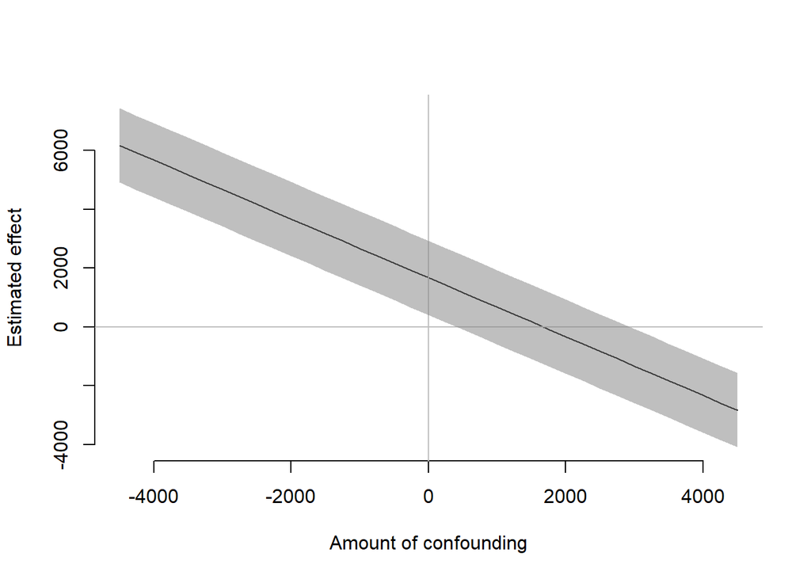

```r
alpha <- seq(-4500, 4500, by = 250)
ll.sens <- causalsens(ymodel, pmodel, ~ age + education, data = lalonde.exp,
alpha = alpha, confound = one.sided.att)

plot(ll.sens, type = "raw", bty = "n")
```

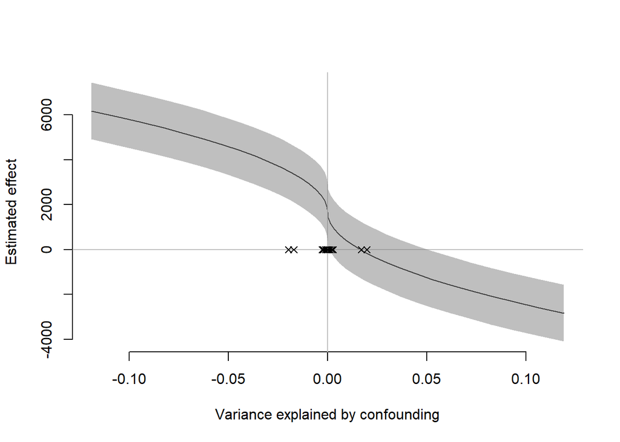

```r
plot(ll.sens, type = "r.squared", bty = "n")
```

We first pick some covariates $X$ to create our propensity score.

- Pick the gender variable, and check the distribution of variable `gender_inp`  
  From the data documentation, the level of `gender_inp` is:
- 0 Male
- 1 Female
- 2 Transgender: M to F
- 3 Transgender F to M
- Pick the age variable, and check the distribution of variable `age_inp`.

```r
table(pcs8_score_inp.Data$gender_inp)
```

```
##
##    0    1    2    3
## 5296 6904    1    3
```

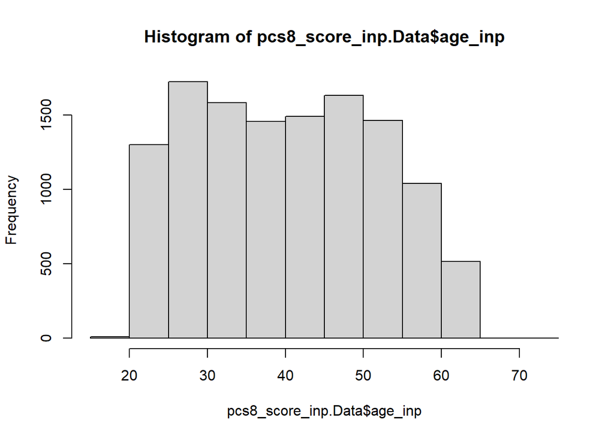

```r
hist(pcs8_score_inp.Data$age_inp)
```

- First do sensitivity analysis to the response variable pcs8_score.

We first run the usual outcome regression, set the pcs8 score as response variable, and model covariates as gender, age, treatment.  
Secondly, we run the logistic regression of treatment on age and gender. Interestingly, we can see age and gender do not explain the variable of treatment assignment significantly. That is what we want to see, as we have used the instrumental variable to control the treatment assignment bias.

```r
pcs8_score_inp.Data$gender_inp = as.factor(pcs8_score_inp.Data$gender_inp)

# the original model
ymodel <- lm(pcs8_score_inp ~ treatment +age_inp+gender_inp, data =pcs8_score_inp.Data)
summary(ymodel)
```

```
##
## Call:
## lm(formula = pcs8_score_inp ~ treatment + age_inp + gender_inp,
##     data = pcs8_score_inp.Data)
##
## Residuals:
##     Min      1Q  Median      3Q     Max
## -34.243  -6.786   1.802   7.606  24.175
##
## Coefficients:
##              Estimate Std. Error t value Pr(>|t|)
## (Intercept) 56.437143   0.358831 157.280  < 2e-16 ***
## treatment    0.495704   0.180858   2.741  0.00614 **
## age_inp     -0.245016   0.007732 -31.687  < 2e-16 ***
## gender_inp1 -1.790278   0.182391  -9.816  < 2e-16 ***
## gender_inp2 -6.394007   9.980076  -0.641  0.52174
## gender_inp3 -6.184156   5.763096  -1.073  0.28326
## ---
## Signif. codes:  0 '***' 0.001 '**' 0.01 '*' 0.05 '.' 0.1 ' ' 1
##
## Residual standard error: 9.977 on 12197 degrees of freedom
##   (1 observation deleted due to missingness)
## Multiple R-squared:  0.0817, Adjusted R-squared:  0.08132
## F-statistic:   217 on 5 and 12197 DF,  p-value: < 2.2e-16
```

```r
#the model for the propensity score
pmodel <- glm(treatment~age_inp+gender_inp,data=pcs8_score_inp.Data,family = binomial())

summary(pmodel)
```

```
##
## Call:
## glm(formula = treatment ~ age_inp + gender_inp, family = binomial(),
##     data = pcs8_score_inp.Data)
##
## Deviance Residuals:
##    Min      1Q  Median      3Q     Max
## -1.491  -1.213   1.115   1.141   1.169
##
## Coefficients:
##               Estimate Std. Error z value Pr(>|z|)
## (Intercept)  -0.016190   0.069712  -0.232    0.816
## age_inp       0.002874   0.001552   1.852    0.064 .
## gender_inp1  -0.020511   0.036605  -0.560    0.575
## gender_inp2 -10.728023 119.468050  -0.090    0.928
## gender_inp3   0.629858   1.225264   0.514    0.607
## ---
## Signif. codes:  0 '***' 0.001 '**' 0.01 '*' 0.05 '.' 0.1 ' ' 1
##
## (Dispersion parameter for binomial family taken to be 1)
##
##     Null deviance: 16893  on 12202  degrees of freedom
## Residual deviance: 16887  on 12198  degrees of freedom
##   (1 observation deleted due to missingness)
## AIC: 16897
##
## Number of Fisher Scoring iterations: 9
```

- Assume the confounding structure is the one-sided bias structure and set different $\alpha$ to see the causal effects. We can notice with the use of instrumental variable, we did not really see any unmeasured confounding issue. Thus, we cannot see shaded region. Although, this model still gives a narrow interval for the causal effect. We pull out the first ten rows of sensitivity analysis to show it.

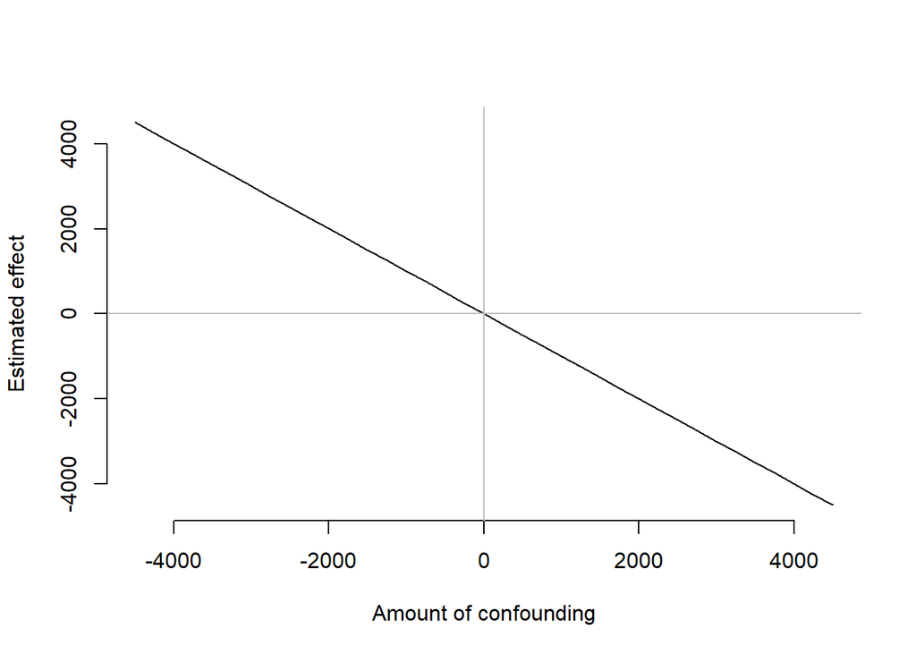

```r
alpha <- seq(-4500, 4500, by = 250)
ll.sens <- causalsens(ymodel, pmodel, ~ age_inp + gender_inp, data = pcs8_score_inp.Data,alpha = alpha, confound = one.sided.att)

plot(ll.sens, type = "raw", bty = "n")
```

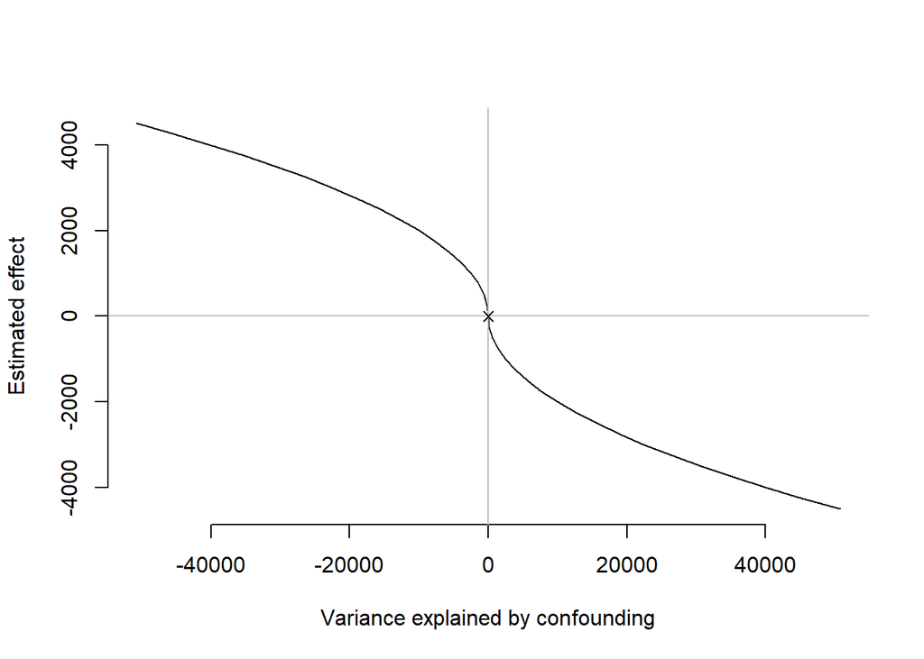

```r
plot(ll.sens, type = "r.squared", bty = "n")
```

```r
ll.sens$sens[1:10,]
```

```
##        rsqs alpha estimate    lower   upper
## 1  50778.44 -4500 4500.496 4500.141 4500.85
## 2  45293.11 -4250 4250.496 4250.141 4250.85
## 3  40121.23 -4000 4000.496 4000.141 4000.85
## 4  35262.80 -3750 3750.496 3750.141 3750.85
## 5  30717.82 -3500 3500.496 3500.141 3500.85
## 6  26486.28 -3250 3250.496 3250.141 3250.85
## 7  22568.19 -3000 3000.496 3000.141 3000.85
## 8  18963.55 -2750 2750.496 2750.141 2750.85
## 9  15672.36 -2500 2500.496 2500.141 2500.85
## 10 12694.61 -2250 2250.496 2250.141 2250.85
```

Now we could do the same analysis for the `health_change_inp` variable and `phqtot_inp` variable.

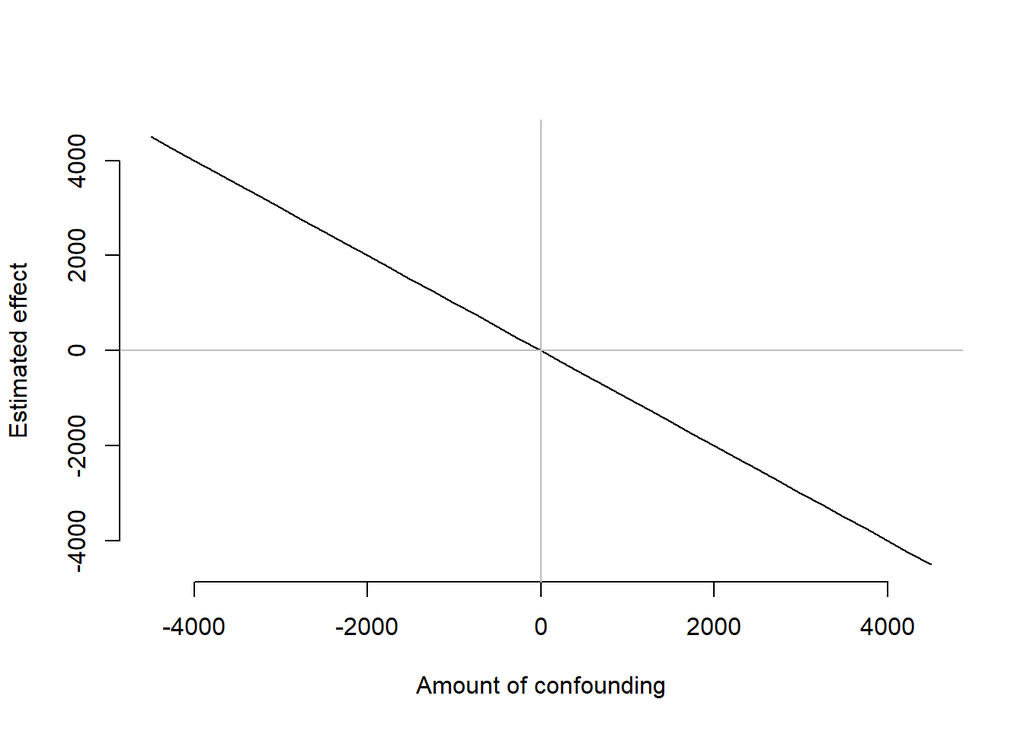

```r
health.Change.Data$gender_inp = as.factor(health.Change.Data$gender_inp)

# the original model
ymodel <- lm(health_change_inp ~ treatment +age_inp+gender_inp, data =health.Change.Data)


#the model for the propensity score
pmodel <- glm(treatment~age_inp+gender_inp,data=health.Change.Data,family = binomial())

alpha <- seq(-4500, 4500, by = 250)
ll.sens <- causalsens(ymodel, pmodel, ~ age_inp + gender_inp, data = health.Change.Data,alpha = alpha, confound = one.sided.att)

plot(ll.sens, type = "raw", bty = "n")
```

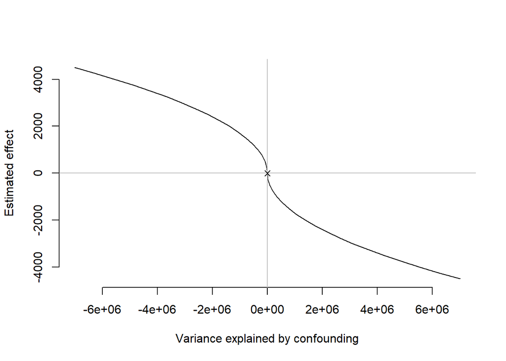

```r
plot(ll.sens, type = "r.squared", bty = "n")
```

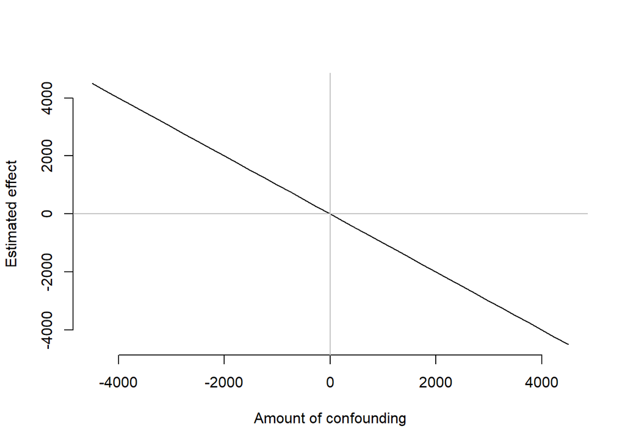

```r
phqtot_inp.Data$gender_inp = as.factor(phqtot_inp.Data$gender_inp)

# the original model
ymodel <- lm(phqtot_inp ~ treatment +age_inp+gender_inp, data =phqtot_inp.Data)


#the model for the propensity score
pmodel <- glm(treatment~age_inp+gender_inp,data=phqtot_inp.Data,family = binomial())

alpha <- seq(-4500, 4500, by = 250)
ll.sens <- causalsens(ymodel, pmodel, ~ age_inp + gender_inp, data = phqtot_inp.Data,alpha = alpha, confound = one.sided.att)

plot(ll.sens, type = "raw", bty = "n")
```

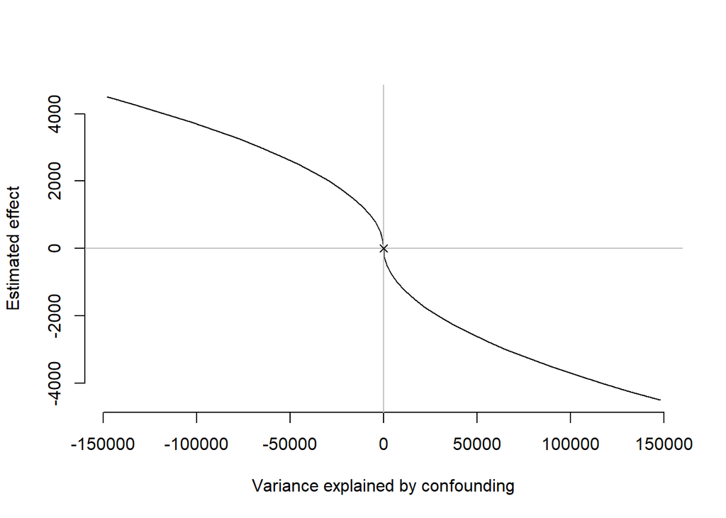

```r
plot(ll.sens, type = "r.squared", bty = "n")
```

# Conclusion and Future Direction

From the theoretical perspective, we showed that the use of instrumental variable could avoid unmeasured confounding issue. On the application side, we showed that insurance improved an individual’s overall health.  
As for the sensitivity analysis part, we showed that a way to conduct sensitivity analysis is to assume the structure, also the possible range of sensitivity parameter, and to see if our final causal effect conclusion still holds. One of the future research direction is to discuss how to conquer the problem of scale-variant sensitivity parameter.  
In particular, the quantity we used in our sensitivity analysis, is defined to be the difference

$$q(a,x) = \mathbb{E}(Y_i(a)|A_i=a,X_i=x) -
\mathbb{E}(Y_i(a)|A_i=1-a,X_i=x)$$

And one should notice that this quantity would be difference based on the unit we set, for example, if we use kilogram instead of pound to measure the causal impact of a covariate $X$ on weight $Y$, then the quantity would be different. This might not be a desired property.